# Trabajo Práctico 1: Análisis Exploratorio e Introducción a Regresión lineal

# Análisis exploratorio (II)

Se crea la variable precio en miles dividiendo *price* por 1000, obtenemos estadísticas descriptivas de la misma y realizamos un histograma.

```r
# Agregamos la variable precio en miles de dolares
Properties_Clean <- Properties_Clean %>%
                   mutate(precio_en_miles = price/1000)

summary(Properties_Clean$precio_en_miles)  #Estadísticas descriptivas
```

```
##    Min. 1st Qu.  Median    Mean 3rd Qu.    Max.
##     6.0   119.0   170.0   251.6   270.0  6000.0
```

[figure not shown]

```r
# Graficamos el histograma y modelamos una normal
ggplot(Properties_Clean,aes( x=precio_en_miles)) +
  geom_histogram( aes(y=..density..),
                  breaks = seq(0,3000,by=100),
                  colour="black",
                  fill = "white",) +
  stat_function(fun = dnorm, args = list(mean=mean(Properties_Clean$precio_en_miles), sd= sd(Properties_Clean$precio_en_miles)))
```

Verificamos las características de la variable pero aperturando por el tipo de propiedad.

```r
# Estadísticas descriptivas por grupo, dropeando los niveles que no tienen ocurrencias ( casa de campo, cochera, etc)
Properties_Clean %>%
  select("precio_en_miles","property_type") %>%
  split(.$property_type,drop = TRUE) %>%
  map(summary)
```

```
## $Casa
##  precio_en_miles          property_type
##  Min.   :  20.0   Casa           :1913
##  1st Qu.: 235.0   Casa de campo  :   0
##  Median : 330.0   Cochera        :   0
##  Mean   : 433.4   DepÃ³sito      :   0
##  3rd Qu.: 490.0   Departamento   :   0
##  Max.   :5000.0   Local comercial:   0
##                   (Other)        :   0
##
## $Departamento
##  precio_en_miles          property_type
##  Min.   :   6.0   Departamento   :44022
##  1st Qu.: 115.0   Casa           :    0
##  Median : 164.9   Casa de campo  :    0
##  Mean   : 247.4   Cochera        :    0
##  3rd Qu.: 260.0   DepÃ³sito      :    0
##  Max.   :6000.0   Local comercial:    0
##                   (Other)        :    0
##
## $PH
##  precio_en_miles        property_type
##  Min.   :  32.0   PH           :4893
##  1st Qu.: 137.0   Casa         :   0
##  Median : 190.0   Casa de campo:   0
##  Mean   : 218.5   Cochera      :   0
##  3rd Qu.: 270.0   DepÃ³sito    :   0
##  Max.   :1500.0   Departamento :   0
##                   (Other)      :   0
```

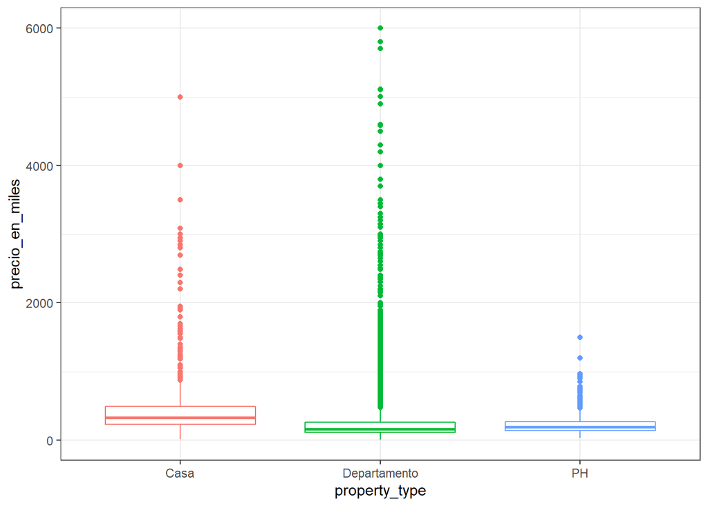

```r
# Boxplot del precio por tipo de propiedad
ggplot(data = Properties_Clean,
       mapping = aes(x = property_type, y = precio_en_miles, colour = property_type)) +
  geom_boxplot() +
  theme_bw() +
  theme(legend.position = "none")
```

En los boxplots, se observa un valor en promedio mayor del precio para las casas, teniendo una mediana y un rango intercuartil mayor. Sin embargo, los outliers no permiten una buena apreciación del gráfico, habiendo una mayor cantidad de los mismos en el caso de departamentos.

Procedemos a utilizar la función *ggpairs* para realizar un análisis más profundo.

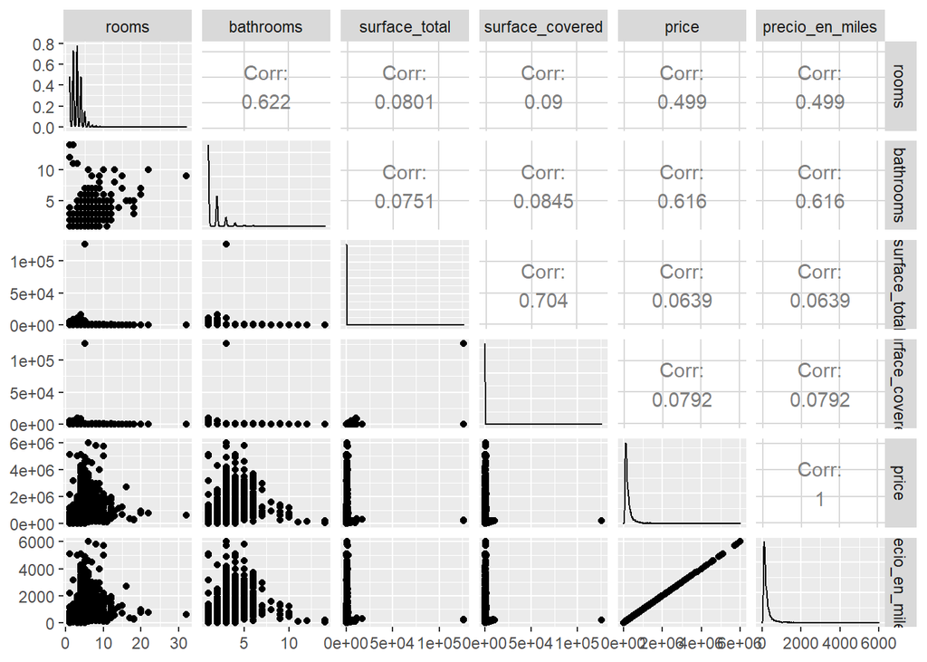

```r
# ggpairs a varibales numericas
Properties_Clean %>%
  select_if(is.numeric) %>%
  ggpairs(progress = FALSE)
```

# Outliers

Gráficamos un scatterplot para el precio y la superficie total.

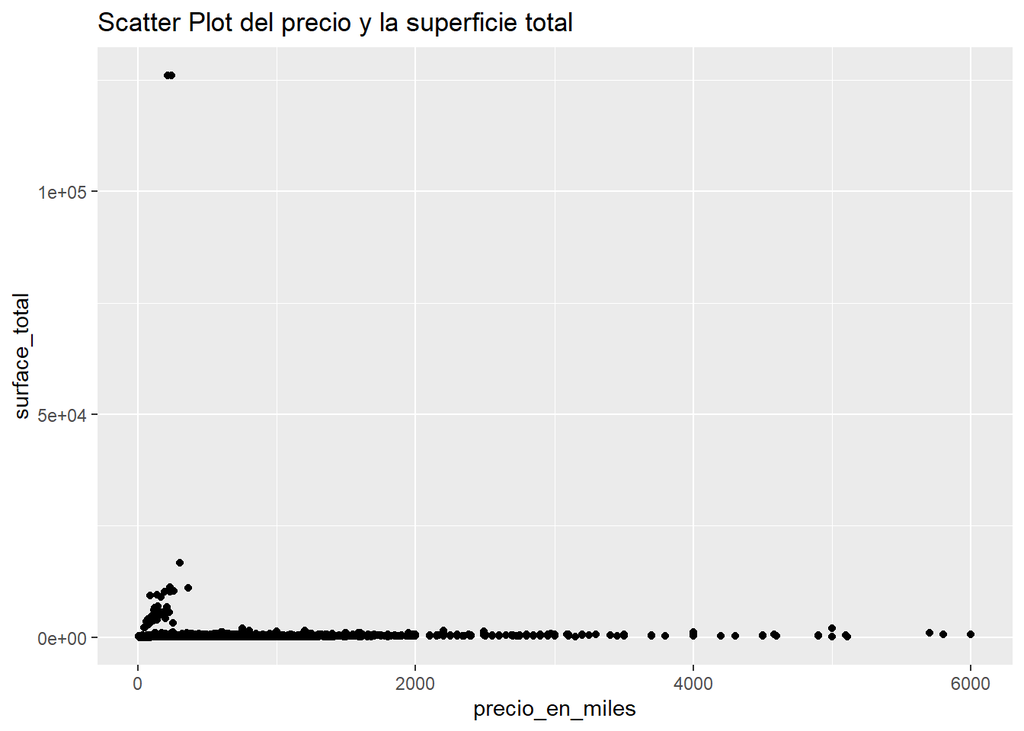

```r
# Hay un par de puntos con valores muy altos de superficie
ggplot(Properties_Clean,aes(x=precio_en_miles,y=surface_total)) +
    geom_point() +
    ggtitle("Scatter Plot del precio y la superficie total")
```

Algunos registros tienen valores muy altos de superficie, lo cual distorsiona el análisis. Procedemos a borrar los outliers con un criterio del rango intercuartil ( outliers severos, en donde el IQR es multiplicado por 3 para obtener los límites inferiores y superiores).

Luego de eliminar outliers, se repiten los análisis.

```r
Properties_NoOutliers = Properties_Clean %>%
                        map_if(is.numeric,delete_outliers_IQR) %>%  # Llevamos los outliers univariados a NA
                        data.frame() %>%
                        drop_na()
```

# Análisis exploratorio III

Repetimos los análisis del punto 4 junto con un scatterplot

```r
summary(Properties_NoOutliers$precio_en_miles)
```

```
##    Min. 1st Qu.  Median    Mean 3rd Qu.    Max.
##     6.0   115.0   163.0   200.2   250.0   720.0
```

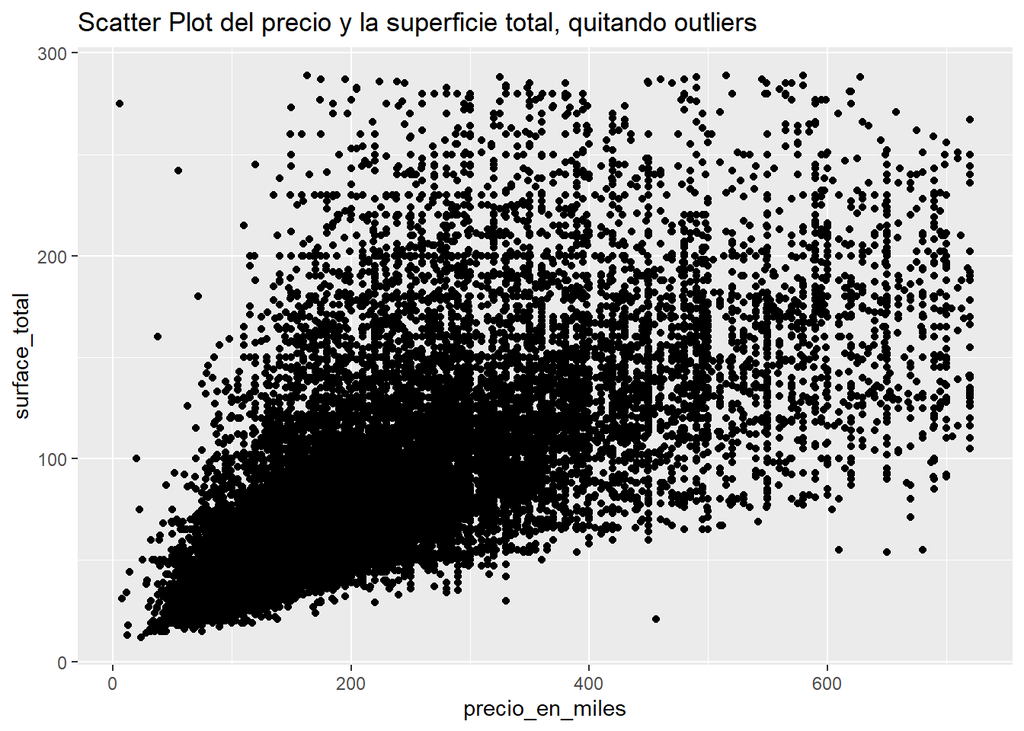

```r
ggplot(Properties_NoOutliers,aes(x=precio_en_miles,y=surface_total)) +
    geom_point() +
    ggtitle("Scatter Plot del precio y la superficie total, quitando outliers")
```

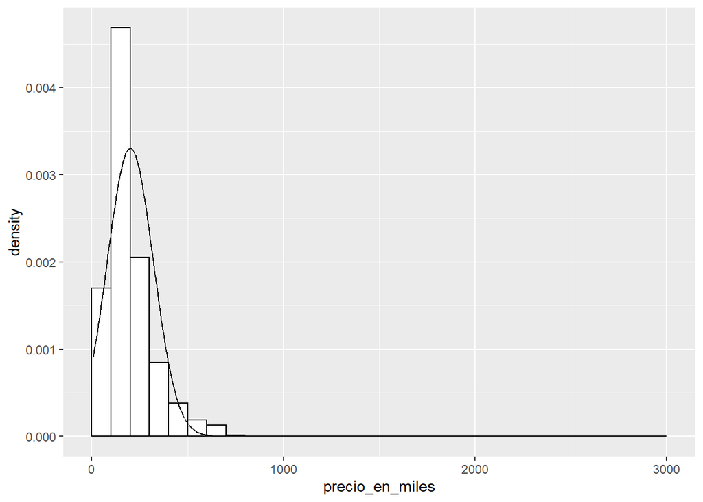

```r
ggplot(Properties_NoOutliers,aes( x=precio_en_miles)) +
  geom_histogram( aes(y=..density..),
                  breaks = seq(0,3000,by=100),
                  colour="black",
                  fill = "white") +
  stat_function(fun = dnorm, args = list(mean=mean(Properties_NoOutliers$precio_en_miles), sd= sd(Properties_NoOutliers$precio_en_miles)))
```

```r
Properties_NoOutliers %>%
  select("price","property_type") %>%
  split(.$property_type,drop = TRUE) %>%
  map(summary)
```

```
## $Casa
##      price                property_type
##  Min.   : 20000   Casa           :1219
##  1st Qu.:195000   Casa de campo  :   0
##  Median :275000   Cochera        :   0
##  Mean   :286387   DepÃ³sito      :   0
##  3rd Qu.:359500   Departamento   :   0
##  Max.   :720000   Local comercial:   0
##                   (Other)        :   0
##
## $Departamento
##      price                property_type
##  Min.   :  6000   Departamento   :41832
##  1st Qu.:113000   Casa           :    0
##  Median :159000   Casa de campo  :    0
##  Mean   :197013   Cochera        :    0
##  3rd Qu.:240000   DepÃ³sito      :    0
##  Max.   :720000   Local comercial:    0
##                   (Other)        :    0
##
## $PH
##      price              property_type
##  Min.   : 32000   PH           :4597
##  1st Qu.:134900   Casa         :   0
##  Median :183000   Casa de campo:   0
##  Mean   :206137   Cochera      :   0
##  3rd Qu.:260000   DepÃ³sito    :   0
##  Max.   :710000   Departamento :   0
##                   (Other)      :   0
```

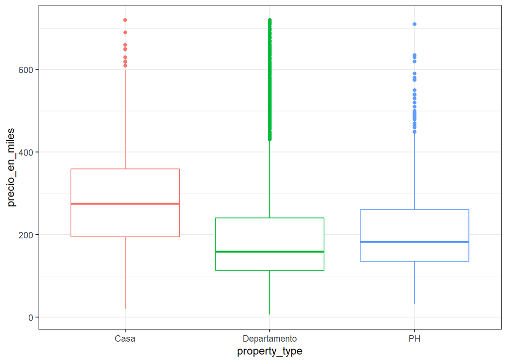

```r
ggplot(data = Properties_NoOutliers, mapping = aes(x = property_type, y = precio_en_miles, colour = property_type)) +
  geom_boxplot() + theme_bw() + theme(legend.position = "none")
```

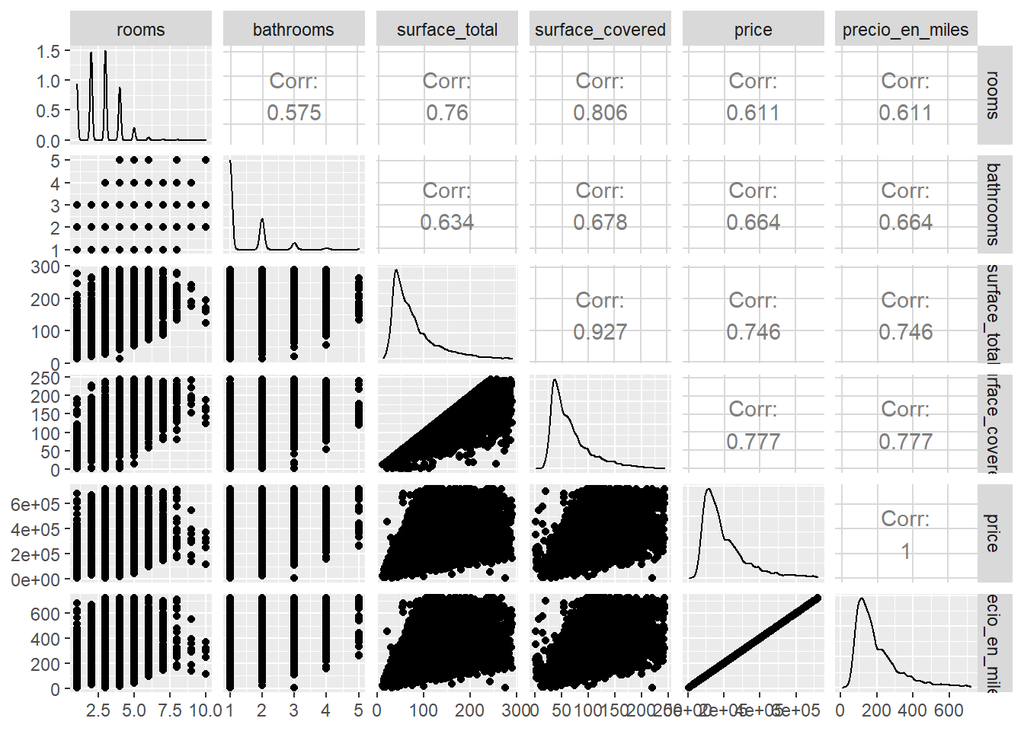

```r
Properties_NoOutliers %>%
  select_if(is.numeric) %>%
  ggpairs(progress = FALSE)
```

La diferencia es muy clara al hacer el scatter plot entre las variables y también al analizar las correlaciones. Los outliers distorsionaron las medidas y en el caso del scatter plot, no dejaban observar la relación presente entre las variables. Es importante resaltar que al eliminar los outliers, la correlación del precio y las variables de superficie aumentó considerablemente.

Lo observado en los boxplots anteriores se puede apreciar en mayor detalle esta vez, las casas tienden a tener valores mas grandes, siendo PH y departamento similares en general. Nuevamente, los departamentos son los que mas valores extremos tienen.

El nuevo scatter plot permite inferir una relación entre la superficie de una propiedad y su precio, lo cual justifica realizar un modelo lineal y observar los valores de sus estadísticos.

# Modelo Lineal

Se realizan los modelos lineales para las variables pedidas:

```r
model_rooms= lm(formula = precio_en_miles ~ rooms, data = Properties_NoOutliers)
summary(model_rooms)
```

```
##
## Call:
## lm(formula = precio_en_miles ~ rooms, data = Properties_NoOutliers)
##
## Residuals:
##     Min      1Q  Median      3Q     Max
## -540.32  -57.18  -14.05   30.95  581.54
##
## Coefficients:
##             Estimate Std. Error t value Pr(>|t|)
## (Intercept)  36.5968     1.0656   34.34   <2e-16 ***
## rooms        61.8624     0.3673  168.40   <2e-16 ***
## ---
## Signif. codes:  0 '***' 0.001 '**' 0.01 '*' 0.05 '.' 0.1 ' ' 1
##
## Residual standard error: 95.62 on 47646 degrees of freedom
## Multiple R-squared:  0.3731, Adjusted R-squared:  0.3731
## F-statistic: 2.836e+04 on 1 and 47646 DF,  p-value: < 2.2e-16
```

```r
tidy(model_rooms)
```

```
## # A tibble: 2 x 5
##   term        estimate std.error statistic   p.value
##   <chr>          <dbl>     <dbl>     <dbl>     <dbl>
## 1 (Intercept)     36.6     1.07       34.3 2.25e-255
## 2 rooms           61.9     0.367     168.  0.
```

```r
#plot(model_rooms)
```

Se puede ver que el t value es muy alto y el p-value es muy bajo. Esto permite rechazar la hipótesis de que la pendiente de la recta sea 0. Los coeficientes estimados poseen además un error estandar pequeño. A continuación se analizará el modelo lineal a partir de la variable superficie, que en los scatter plots parecía tener una relación mayor. Una posible forma de comparación entre los modelos es el coeficiente de determinación, que explica la proporción de variabilidad del fenómeno que logra explicar el modelo. En este caso, su valor es de alrededor de 0.37

```r
model_surface= lm(formula = precio_en_miles ~ surface_total, data = Properties_NoOutliers)
summary(model_surface)
```

```
##
## Call:
## lm(formula = precio_en_miles ~ surface_total, data = Properties_NoOutliers)
##
## Residuals:
##     Min      1Q  Median      3Q     Max
## -581.05  -36.96  -11.96   25.14  523.04
##
## Coefficients:
##                Estimate Std. Error t value Pr(>|t|)
## (Intercept)   49.432595   0.718901   68.76   <2e-16 ***
## surface_total  1.954964   0.008004  244.25   <2e-16 ***
## ---
## Signif. codes:  0 '***' 0.001 '**' 0.01 '*' 0.05 '.' 0.1 ' ' 1
##
## Residual standard error: 80.47 on 47646 degrees of freedom
## Multiple R-squared:  0.556,  Adjusted R-squared:  0.556
## F-statistic: 5.966e+04 on 1 and 47646 DF,  p-value: < 2.2e-16
```

```r
tidy(model_surface)
```

```
## # A tibble: 2 x 5
##   term          estimate std.error statistic p.value
##   <chr>            <dbl>     <dbl>     <dbl>   <dbl>
## 1 (Intercept)      49.4    0.719        68.8       0
## 2 surface_total     1.95   0.00800     244.        0
```

```r
#plot(model_surface)
```

Efectivamente, se observa un t value mas grande y un p-valor muy chico. Por otro lado, la métrica del R-squared que permite ver cuanta variabilidad de la variable original capturamos con el modelo, posee un valor mas grande. Las métricas obtenidas sugieren que el modelo de superficie permite una predicción más fiable del precio.